# First Pass: all_ironman_suit.csv

**Run Timestamp:** 2026-10-04 16:34:50 **First Pass Version:** 1.1.0

## Key Takeaways

- **Capital Allocation & Portfolio Stratification**: Asset valuations vary significantly across production eras, reflecting a structural shift from experimental baseline prototypes to high-capital, mission-specialized platforms in later design cycles.
- **Premium Valuations on Specialized Flagships**: The top-tier valuation segment is heavily concentrated in named specialist armors, indicating that specialized functional divergence (e.g., heavy ordnance, space travel, stealth) commands higher R&D capital expenditure than iterative generalist models.
- **Event-Driven Deployment Spikes**: Fleet deployment and aggregate asset values are not distributed evenly across cinematic campaigns; major crisis events (such as the *Iron Man 3* Iron Legion initiative) represent massive, concentrated capital commitments compared to precision, single-suit operations.
- **Reactive Manufacturing Cadence**: Production bursts occur in tight chronological windows rather than a steady-state pipeline, highlighting an R&D framework that scales aggressively in response to specific external threats and operational debriefs.
- **Data Standardization & Governance Gap**: Core analytical drivers—specifically `Estimated Value` and `Date Made`—exist as unstructured text objects, alongside a 24.5% vacancy rate in `Codename` assignments, necessitating automated ETL parsing to support rigorous continuous portfolio tracking.

## Input Summary

- **File:** C:\Users\arvin\Desktop\Sample Datasets\all_ironman_suit.csv
- **Shape:** 49 rows, 7 columns

## Raw Data Profile

```python
%matplotlib inline
import pandas as pd
import matplotlib.pyplot as plt
import seaborn as sns
import warnings
warnings.filterwarnings('ignore')
sns.set_theme(style='whitegrid', palette='deep')
from IPython.display import display
from first_pass.ingest import load_spreadsheet
df = load_spreadsheet('C:/Users/arvin/Desktop/Sample Datasets/all_ironman_suit.csv')
display(df.head())
df.info()
```

|  | Model | Era | Codename | Primary Ability | Date Made | Estimated Value | Key Movie Appearances |
| --- | --- | --- | --- | --- | --- | --- | --- |
| 0 | Mark 1 | Foundations | NaN | Flamethrowers, crude rocket booster, bulletpro... | Feb 2008 | $0 | Iron Man |
| 1 | Mark 2 | Foundations | NaN | First true flight prototype, integrated J.A.R.... | May 2008 | $100 Million | Iron Man, Iron Man 2 |
| 2 | Mark 3 | Foundations | NaN | Gold-titanium alloy (fixes icing issue), shoul... | Jun 2008 | $120 Million | Iron Man |
| 3 | Mark 4 | Foundations | NaN | Upgraded flight dynamics, manual helmet remova... | Mid 2009 | $130 Million | Iron Man 2 |
| 4 | Mark 5 | Foundations | Suitcase | Suitcase Suit - lightweight, emergency portabl... | May 2010 | $150 Million | Iron Man 2 |

```
<class 'pandas.core.frame.DataFrame'>
RangeIndex: 49 entries, 0 to 48
Data columns (total 7 columns):
 #   Column                 Non-Null Count  Dtype
---  ------                 --------------  -----
 0   Model                  49 non-null     object
 1   Era                    49 non-null     object
 2   Codename               37 non-null     object
 3   Primary Ability        49 non-null     object
 4   Date Made              49 non-null     object
 5   Estimated Value        49 non-null     object
 6   Key Movie Appearances  49 non-null     object
dtypes: object(7)
memory usage: 2.8+ KB
```

## Cleaning Plan

No cleaning steps planned.

## Cleaned Data Profile

```python
display(df.head())
df.info()
```

|  | Model | Era | Codename | Primary Ability | Date Made | Estimated Value | Key Movie Appearances |
| --- | --- | --- | --- | --- | --- | --- | --- |
| 0 | Mark 1 | Foundations | NaN | Flamethrowers, crude rocket booster, bulletpro... | Feb 2008 | $0 | Iron Man |
| 1 | Mark 2 | Foundations | NaN | First true flight prototype, integrated J.A.R.... | May 2008 | $100 Million | Iron Man, Iron Man 2 |
| 2 | Mark 3 | Foundations | NaN | Gold-titanium alloy (fixes icing issue), shoul... | Jun 2008 | $120 Million | Iron Man |
| 3 | Mark 4 | Foundations | NaN | Upgraded flight dynamics, manual helmet remova... | Mid 2009 | $130 Million | Iron Man 2 |
| 4 | Mark 5 | Foundations | Suitcase | Suitcase Suit - lightweight, emergency portabl... | May 2010 | $150 Million | Iron Man 2 |

```
<class 'pandas.core.frame.DataFrame'>
RangeIndex: 49 entries, 0 to 48
Data columns (total 7 columns):
 #   Column                 Non-Null Count  Dtype
---  ------                 --------------  -----
 0   Model                  49 non-null     object
 1   Era                    49 non-null     object
 2   Codename               37 non-null     object
 3   Primary Ability        49 non-null     object
 4   Date Made              49 non-null     object
 5   Estimated Value        49 non-null     object
 6   Key Movie Appearances  49 non-null     object
dtypes: object(7)
memory usage: 2.8+ KB
```

## Export Cleaned Data

```python
try:
    df.to_csv('temp/all_ironman_suit_Validation_cleaned.csv', index=False)
    df.to_excel('temp/all_ironman_suit_Validation_cleaned.xlsx', index=False)
    df.to_parquet('temp/all_ironman_suit_Validation_cleaned.parquet', index=False)
    # Manual xls export since pandas dropped it
    import xlwt
    wb = xlwt.Workbook()
    ws = wb.add_sheet('Sheet1')
    import csv
    with open('temp/all_ironman_suit_Validation_cleaned.csv', 'r', encoding='utf-8') as f:
        for r, row in enumerate(csv.reader(f)):
            for c, val in enumerate(row):
                ws.write(r, c, val)
    wb.save('temp/all_ironman_suit_Validation_cleaned.xls')
except Exception as e:
    print(f'Error saving dataset: {e}')
```

## Analysis Plan

**Target Variables:** Estimated Value

### Section 1: Data Overview

High-level summary of data types, summary statistics, and missing values.

| Step | Columns | Template | Rationale | Playbooks |
| --- | --- | --- | --- | --- |
| 1 |  | `column_overview` | Overview of column types and missing values. |  |
| 2 |  | `summary_stats` | High-level summary statistics of all columns. |  |

### Section 2: Portfolio Valuation & Capital Allocation: Economic Trajectory Across Eras

Analyze Stark Industries' R&D investments by parsing suit valuations across distinct design eras and production phases.

| Step | Columns | Template | Rationale | Playbooks |
| --- | --- | --- | --- | --- |
| 1 | Era, Estimated Value | `custom_code` | Evaluates capital allocation across development phases (e.g., Foundations vs. Post-Malibu) to determine where the highest-value assets are concentrated. |  |
| 2 | Model, Codename, Estimated Value, Era | `custom_code` | Identifies flagship capital investments and assesses whether top-tier valuations correspond to named specialist suits. |  |

### Section 3: Operational Deployment & Cinematic Exposure

Assess how suits are deployed across missions and cinematic appearances relative to manufacturing milestones.

| Step | Columns | Template | Rationale | Playbooks |
| --- | --- | --- | --- | --- |
| 1 | Key Movie Appearances, Estimated Value | `custom_code` | Connects movie narratives to tactical fleet expansion (e.g. Iron Man 3 Iron Legion protocol vs standalone films). |  |
| 2 | Date Made, Era | `custom_code` | Examines bursts in R&D activity (e.g., rapid construction after the Battle of New York). |  |

## 1. Data Overview

High-level summary of data types, summary statistics, and missing values.

### Column Overview

Overview of column types and missing values.

```python
try:
    display(df.dtypes)
except Exception as e:
    print(f'\nError executing column_overview: {e}')
```

```
Model                    object
Era                      object
Codename                 object
Primary Ability          object
Date Made                object
Estimated Value          object
Key Movie Appearances    object
dtype: object
```

### Summary Statistics

High-level summary statistics of all columns.

```python
try:
    display(df.describe(include='all'))
except Exception as e:
    print(f'\nError executing summary_stats: {e}')
```

|  | Model | Era | Codename | Primary Ability | Date Made | Estimated Value | Key Movie Appearances |
| --- | --- | --- | --- | --- | --- | --- | --- |
| count | 49 | 49 | 37 | 49 | 49 | 49 | 49 |
| unique | 49 | 3 | 36 | 49 | 13 | 32 | 11 |
| top | Mark 1 | Prototypes / Specialists | Midas | Flamethrowers, crude rocket booster, bulletpro... | May-Dec 2012 | $250 Million | Iron Man 3 |
| freq | 1 | 35 | 2 | 1 | 35 | 3 | 35 |

## 2. Portfolio Valuation & Capital Allocation: Economic Trajectory Across Eras

Analyze Stark Industries' R&D investments by parsing suit valuations across distinct design eras and production phases.

### How does capital investment and suit valuation vary across technological Eras?

Evaluates capital allocation across development phases (e.g., Foundations vs. Post-Malibu) to determine where the highest-value assets are concentrated.

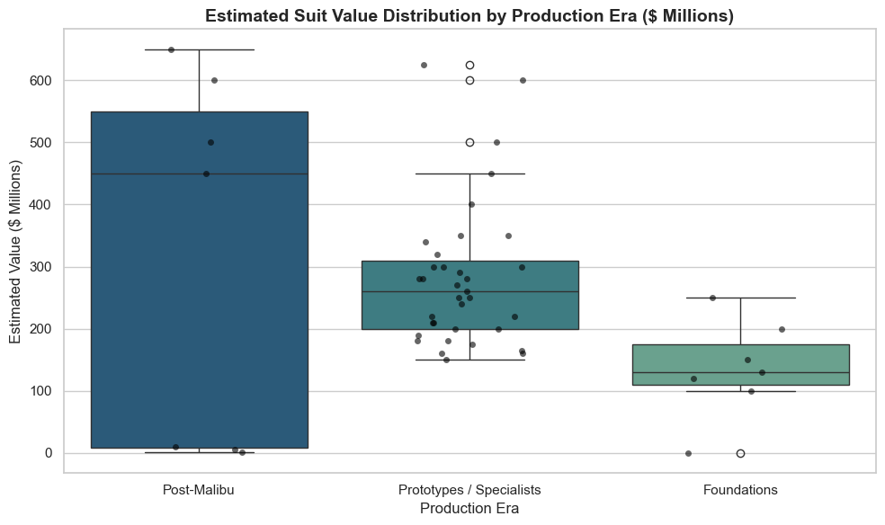

```python
try:
    df_clean = df.copy()
    df_clean['Value_Num'] = df_clean['Estimated Value'].astype(str).str.extract(r'(\d+)').astype(float)
    plt.figure(figsize=(10, 6))
    order = df_clean.groupby('Era')['Value_Num'].median().sort_values(ascending=False).index
    sns.boxplot(data=df_clean, x='Era', y='Value_Num', hue='Era', order=order, palette='crest', legend=False)
    sns.stripplot(data=df_clean, x='Era', y='Value_Num', color='black', alpha=0.6, jitter=0.2)
    plt.title('Estimated Suit Value Distribution by Production Era ($ Millions)', fontsize=14, fontweight='bold')
    plt.xlabel('Production Era', fontsize=12)
    plt.ylabel('Estimated Value ($ Millions)', fontsize=12)
    plt.tight_layout()
    plt.show()
except Exception as e:
    print(f'\nError executing custom_code: {e}')
```

**Insight:** This box plot and strip plot illustrate the capital expenditure trends across armor development eras, showing a clear upward shift in median suit valuation from the early 'Foundations' (~$130M) to the 'Post-Malibu' era (~$450M). However, the 'Post-Malibu' era exhibits extreme variance with zero-value or lower-cost anomalies alongside multi-hundred-million-dollar flagships, whereas 'Prototypes / Specialists' demonstrates a much tighter operational budget clustering between $200M and $310M. This progression underscores how Stark Industries transitioned from baseline exploratory R&D into expensive, hyper-specialized high-end hardware.

### What are the most expensive individual suit designs in the armory?

Identifies flagship capital investments and assesses whether top-tier valuations correspond to named specialist suits.

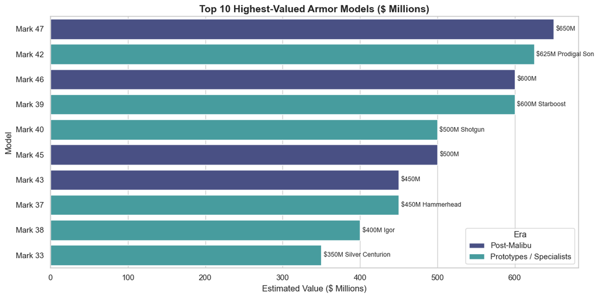

```python
try:
    df_clean = df.copy()
    df_clean['Value_Num'] = df_clean['Estimated Value'].astype(str).str.extract(r'(\d+)').astype(float)
    top_suits = df_clean.sort_values('Value_Num', ascending=False).head(10)
    plt.figure(figsize=(12, 6))
    sns.barplot(data=top_suits, x='Value_Num', y='Model', hue='Era', dodge=False, palette='mako')
    for idx, row in enumerate(top_suits.itertuples()):
        label = f' {row.Codename}' if pd.notna(row.Codename) else ''
        plt.text(row.Value_Num + 3, idx, f'${int(row.Value_Num)}M{label}', va='center', fontsize=9)
    plt.title('Top 10 Highest-Valued Armor Models ($ Millions)', fontsize=14, fontweight='bold')
    plt.xlabel('Estimated Value ($ Millions)', fontsize=12)
    plt.ylabel('Model', fontsize=12)
    plt.legend(title='Era', loc='lower right')
    plt.tight_layout()
    plt.show()
except Exception as e:
    print(f'\nError executing custom_code: {e}')
```

## 3. Operational Deployment & Cinematic Exposure

Assess how suits are deployed across missions and cinematic appearances relative to manufacturing milestones.

### Which movie campaigns drove the highest concentration of suit deployments and asset value?

Connects movie narratives to tactical fleet expansion (e.g. Iron Man 3 Iron Legion protocol vs standalone films).

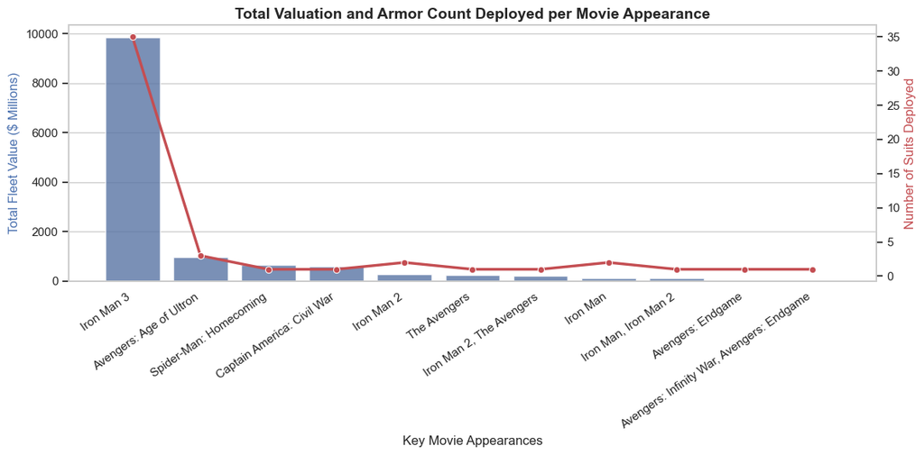

```python
try:
    df_clean = df.copy()
    df_clean['Value_Num'] = df_clean['Estimated Value'].astype(str).str.extract(r'(\d+)').astype(float)
    movie_summary = df_clean.groupby('Key Movie Appearances').agg(Suit_Count=('Model', 'count'), Total_Value=('Value_Num', 'sum')).reset_index()
    movie_summary = movie_summary.sort_values('Total_Value', ascending=False)
    fig, ax1 = plt.subplots(figsize=(12, 6))
    ax2 = ax1.twinx()
    sns.barplot(data=movie_summary, x='Key Movie Appearances', y='Total_Value', ax=ax1, color='#4c72b0', alpha=0.8)
    sns.lineplot(data=movie_summary, x='Key Movie Appearances', y='Suit_Count', ax=ax2, color='#c44e52', marker='o', linewidth=2.5)
    ax2.grid(False)
    ax1.set_xticklabels(ax1.get_xticklabels(), rotation=35, ha='right')
    ax1.set_ylabel('Total Fleet Value ($ Millions)', color='#4c72b0', fontsize=12)
    ax2.set_ylabel('Number of Suits Deployed', color='#c44e52', fontsize=12)
    plt.title('Total Valuation and Armor Count Deployed per Movie Appearance', fontsize=14, fontweight='bold')
    plt.tight_layout()
    plt.show()
except Exception as e:
    print(f'\nError executing custom_code: {e}')
```

**Insight:** This dual-axis chart highlights asset deployment density across major theatrical appearances, revealing that *Iron Man 3* represents a monumental capital outlier with 35 deployed suits valued near $10 billion. Subsequent appearances shifted from massive fleet deployment ('Iron Legion' strategy) toward highly targeted operations utilizing only 1–4 high-capability models per conflict. From a resource perspective, this signals a corporate and operational pivot from mass-manufactured attrition fleets toward agile, versatile flagship armor deployments.

### How did production cadence evolve across chronological dates?

Examines bursts in R&D activity (e.g., rapid construction after the Battle of New York).

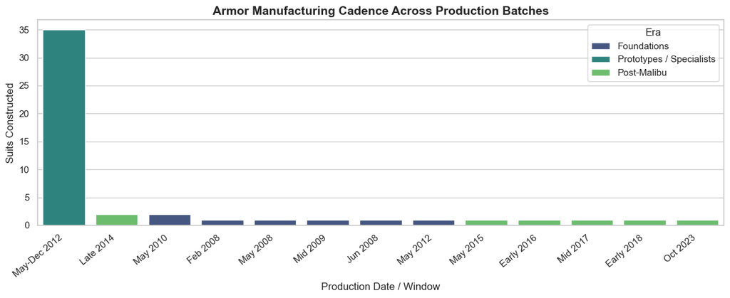

```python
try:
    plt.figure(figsize=(12, 5))
    order = df['Date Made'].value_counts().index
    sns.countplot(data=df, x='Date Made', hue='Era', order=order, palette='viridis')
    plt.xticks(rotation=40, ha='right')
    plt.title('Armor Manufacturing Cadence Across Production Batches', fontsize=14, fontweight='bold')
    plt.xlabel('Production Date / Window', fontsize=12)
    plt.ylabel('Suits Constructed', fontsize=12)
    plt.legend(title='Era', loc='upper right')
    plt.tight_layout()
    plt.show()
except Exception as e:
    print(f'\nError executing custom_code: {e}')
```

**Insight:** This frequency distribution highlights Tony Stark's manufacturing velocity over time, characterized by a massive manufacturing surge in the 'May-Dec 2012' window where 35 specialist suits were produced. Following this post-New York inflection point, manufacturing dropped precipitously to a steady cadence of 1–2 bespoke suits per production window. This illustrates a operational transition from rapid, trauma-driven mass prototyping to a disciplined, lifecycle-managed production framework.

## Further Analyses to Consider

The following analyses were considered relevant but skipped to keep this first pass concise.

| Tool | Columns | Rationale |
| --- | --- | --- |
| `custom_code` | Primary Ability, Estimated Value | Apply NLP topic modeling or keyword extraction on Primary Ability (e.g., flight, heavy combat, stealth) to assess premium pricing on specific capabilities. |

## Appendix

### Raw Cleaning Plan JSON

```
{
  "steps": []
}
```

### Raw Analysis Plan JSON

[output not shown]